# Business Case: Delhivery - Feature Engineering

## About Delhivery

Delhivery is the largest and fastest-growing fully integrated player in India by revenue in Fiscal 2021. They aim to build the operating system for commerce, through a combination of world-class infrastructure, logistics operations of the highest quality, and cutting-edge engineering and technology capabilities.

The Data team builds intelligence and capabilities using this data that helps them to widen the gap between the quality, efficiency, and profitability of their business versus their competitors.

## Dataset column Profiling:

- *data* - tells whether the data is testing or training data
- *trip_creation_time* – Timestamp of trip creation
- *route_schedule_uuid* – Unique Id for a particular route schedule
- *route_type* – Transportation type
  - FTL – Full Truck Load: FTL shipments get to the destination sooner, as the truck is making no other pickups or drop-offs along the way
  - Carting: Handling system consisting of small vehicles (carts)
- *trip_uuid* - Unique ID given to a particular trip (A trip may include different source and destination centers)
- *source_center* - Source ID of trip origin
- *source_name* - Source Name of trip origin
- *destination_cente* – Destination ID
- *destination_name* – Destination Name
- *od_start_time* – Trip start time
- *od_end_time* – Trip end time
- *start_scan_to_end_scan* – Time taken to deliver from source to destination
- *is_cutoff* – Unknown field
- *cutoff_factor* – Unknown field
- *cutoff_timestamp* – Unknown field
- *actual_distance_to_destination* – Distance in Kms between source and destination warehouse
- *actual_time* – Actual time taken to complete the delivery (Cumulative)
- *osrm_time* – An open-source routing engine time calculator which computes the shortest path between points in a given map (Includes usual traffic, distance through major and minor roads) and gives the time (Cumulative)
- *osrm_distance* – An open-source routing engine which computes the shortest path between points in a given map (Includes usual traffic, distance through major and minor roads) (Cumulative)
- *factor* – Unknown field
- *segment_actual_time* – This is a segment time. Time taken by the subset of the package delivery
- *segment_osrm_time* – This is the OSRM segment time. Time taken by the subset of the package delivery
- *segment_osrm_distance* – This is the OSRM distance. Distance covered by subset of the package delivery
- *segment_factor* – Unknown field

## Business problem

The company wants to understand and process the data coming out of data engineering pipelines:

• Clean, sanitize and manipulate data to get useful features out of raw fields

• Make sense out of the raw data and help the data science team to build forecasting models on it

## Our approach to the businesss problem.

The focus of this case-study is to use various feature engineering techniques to generate a dataset which can be used by the Data Science team at Delhivery to build forecasting models. We begin with preliminary EDA to analyze the structure of the given data-set, understand relationship between the given features, spot missing values and outliers, perform uni-variate analysis to understand distributions for continuous features and count distribution for categorical features, and perform bi-variate/multi-variate analysis to understand relations among various features. We then perform aggregation; We first aggregate at (trip, source, destination) level. We then further aggregate at (trip) level and use several visual/hypothesis tests to determine relationship between various aggregated features and also remove outliers wherever necessary. We then use various feature engineering techniques on the aggregated data-set to create new features. Finally, we examine the dataset to further generate business insights and recommendations.

**Basic roadmap**

1. Basic data cleaning and exploration:
   - Handle missing values in the data.
   - Analyze the structure of the data.
   - Try merging the rows using the hint mentioned above.
2. Build some features to prepare the data for actual analysis. Extract features from the below fields:
   - Destination Name: Split and extract features out of destination. City-place-code (State)
   - Source Name: Split and extract features out of destination. City-place-code (State)
   - Trip_creation_time: Extract features like month, year and day etc
3. In-depth analysis and feature engineering:
   - Calculate the time taken between od_start_time and od_end_time and keep it as a feature. Drop the original columns, if required
   - Compare the difference between Point a. and start_scan_to_end_scan. Do hypothesis testing/ Visual analysis to check.
   - Do hypothesis testing/ visual analysis between actual_time aggregated value and OSRM time aggregated value (aggregated values are the values you’ll get after merging the rows on the basis of trip_uuid)
   - Do hypothesis testing/ visual analysis between actual_time aggregated value and segment actual time aggregated value (aggregated values are the values you’ll get after merging the rows on the basis of trip_uuid)
   - Do hypothesis testing/ visual analysis between osrm distance aggregated value and segment osrm distance aggregated value (aggregated values are the values you’ll get after merging the rows on the basis of trip_uuid)
   - Do hypothesis testing/ visual analysis between osrm time aggregated value and segment osrm time aggregated value (aggregated values are the values you’ll get after merging the rows on the basis of trip_uuid)
   - Find outliers in the numerical variables (you might find outliers in almost all the variables), and check it using visual analysis
   - Handle the outliers using the IQR method.
   - Do one-hot encoding of categorical variables (like route_type)
   - Normalize/ Standardize the numerical features using MinMaxScaler or StandardScaler.

# Solution

## Read data and understand its structure

```python
import numpy as np
import pandas as pd
import matplotlib.pyplot as plt
import seaborn as sns

#read dataset
data_original = pd.read_csv('data/delhivery_data.csv')
df = data_original.copy()
df.head()
```

|  | data | trip_creation_time | route_schedule_uuid | route_type | trip_uuid | source_center | source_name | destination_center | destination_name | od_start_time | ... | cutoff_timestamp | actual_distance_to_destination | actual_time | osrm_time | osrm_distance | factor | segment_actual_time | segment_osrm_time | segment_osrm_distance | segment_factor |
| --- | --- | --- | --- | --- | --- | --- | --- | --- | --- | --- | --- | --- | --- | --- | --- | --- | --- | --- | --- | --- | --- |
| 0 | training | 2018-09-20 02:35:36.476840 | thanos::sroute:eb7bfc78-b351-4c0e-a951-fa3d5c3... | Carting | trip-153741093647649320 | IND388121AAA | Anand_VUNagar_DC (Gujarat) | IND388620AAB | Khambhat_MotvdDPP_D (Gujarat) | 2018-09-20 03:21:32.418600 | ... | 2018-09-20 04:27:55 | 10.435660 | 14.0 | 11.0 | 11.9653 | 1.272727 | 14.0 | 11.0 | 11.9653 | 1.272727 |
| 1 | training | 2018-09-20 02:35:36.476840 | thanos::sroute:eb7bfc78-b351-4c0e-a951-fa3d5c3... | Carting | trip-153741093647649320 | IND388121AAA | Anand_VUNagar_DC (Gujarat) | IND388620AAB | Khambhat_MotvdDPP_D (Gujarat) | 2018-09-20 03:21:32.418600 | ... | 2018-09-20 04:17:55 | 18.936842 | 24.0 | 20.0 | 21.7243 | 1.200000 | 10.0 | 9.0 | 9.7590 | 1.111111 |
| 2 | training | 2018-09-20 02:35:36.476840 | thanos::sroute:eb7bfc78-b351-4c0e-a951-fa3d5c3... | Carting | trip-153741093647649320 | IND388121AAA | Anand_VUNagar_DC (Gujarat) | IND388620AAB | Khambhat_MotvdDPP_D (Gujarat) | 2018-09-20 03:21:32.418600 | ... | 2018-09-20 04:01:19.505586 | 27.637279 | 40.0 | 28.0 | 32.5395 | 1.428571 | 16.0 | 7.0 | 10.8152 | 2.285714 |
| 3 | training | 2018-09-20 02:35:36.476840 | thanos::sroute:eb7bfc78-b351-4c0e-a951-fa3d5c3... | Carting | trip-153741093647649320 | IND388121AAA | Anand_VUNagar_DC (Gujarat) | IND388620AAB | Khambhat_MotvdDPP_D (Gujarat) | 2018-09-20 03:21:32.418600 | ... | 2018-09-20 03:39:57 | 36.118028 | 62.0 | 40.0 | 45.5620 | 1.550000 | 21.0 | 12.0 | 13.0224 | 1.750000 |
| 4 | training | 2018-09-20 02:35:36.476840 | thanos::sroute:eb7bfc78-b351-4c0e-a951-fa3d5c3... | Carting | trip-153741093647649320 | IND388121AAA | Anand_VUNagar_DC (Gujarat) | IND388620AAB | Khambhat_MotvdDPP_D (Gujarat) | 2018-09-20 03:21:32.418600 | ... | 2018-09-20 03:33:55 | 39.386040 | 68.0 | 44.0 | 54.2181 | 1.545455 | 6.0 | 5.0 | 3.9153 | 1.200000 |

5 rows × 24 columns

```python
df.shape
```

```
(144867, 24)
```

```python
df.info()
```

```
<class 'pandas.core.frame.DataFrame'>
RangeIndex: 144867 entries, 0 to 144866
Data columns (total 24 columns):
 #   Column                          Non-Null Count   Dtype
---  ------                          --------------   -----
 0   data                            144867 non-null  object
 1   trip_creation_time              144867 non-null  object
 2   route_schedule_uuid             144867 non-null  object
 3   route_type                      144867 non-null  object
 4   trip_uuid                       144867 non-null  object
 5   source_center                   144867 non-null  object
 6   source_name                     144574 non-null  object
 7   destination_center              144867 non-null  object
 8   destination_name                144606 non-null  object
 9   od_start_time                   144867 non-null  object
```

[output cut: 16 more lines]

```python
#check for missing values
df.isna().sum()
```

```
data                                0
trip_creation_time                  0
route_schedule_uuid                 0
route_type                          0
trip_uuid                           0
source_center                       0
source_name                       293
destination_center                  0
destination_name                  261
od_start_time                       0
od_end_time                         0
start_scan_to_end_scan              0
is_cutoff                           0
cutoff_factor                       0
cutoff_timestamp                    0
actual_distance_to_destination      0
actual_time                         0
osrm_time                           0
osrm_distance                       0
factor                              0
segment_actual_time                 0
segment_osrm_time                   0
segment_osrm_distance               0
segment_factor                      0
dtype: int64
```

```python
df.nunique()
```

```
data                                   2
trip_creation_time                 14817
route_schedule_uuid                 1504
route_type                             2
trip_uuid                          14817
source_center                       1508
source_name                         1498
destination_center                  1481
destination_name                    1468
od_start_time                      26369
od_end_time                        26369
start_scan_to_end_scan              1915
is_cutoff                              2
cutoff_factor                        501
cutoff_timestamp                   93180
actual_distance_to_destination    144515
actual_time                         3182
osrm_time                           1531
osrm_distance                     138046
factor                             45641
segment_actual_time                  747
segment_osrm_time                    214
segment_osrm_distance             113799
segment_factor                      5675
dtype: int64
```

```python
#check possible values for the categorical variables
for col in ['data', 'route_type', 'is_cutoff']:
    print(df[col].value_counts())
    print('\n')
```

```
training    104858
test         40009
Name: data, dtype: int64


FTL        99660
Carting    45207
Name: route_type, dtype: int64


True     118749
False     26118
Name: is_cutoff, dtype: int64
```

```python
df.describe()
```

|  | start_scan_to_end_scan | cutoff_factor | actual_distance_to_destination | actual_time | osrm_time | osrm_distance | factor | segment_actual_time | segment_osrm_time | segment_osrm_distance | segment_factor |
| --- | --- | --- | --- | --- | --- | --- | --- | --- | --- | --- | --- |
| count | 144867.000000 | 144867.000000 | 144867.000000 | 144867.000000 | 144867.000000 | 144867.000000 | 144867.000000 | 144867.000000 | 144867.000000 | 144867.00000 | 144867.000000 |
| mean | 961.262986 | 232.926567 | 234.073372 | 416.927527 | 213.868272 | 284.771297 | 2.120107 | 36.196111 | 18.507548 | 22.82902 | 2.218368 |
| std | 1037.012769 | 344.755577 | 344.990009 | 598.103621 | 308.011085 | 421.119294 | 1.715421 | 53.571158 | 14.775960 | 17.86066 | 4.847530 |
| min | 20.000000 | 9.000000 | 9.000045 | 9.000000 | 6.000000 | 9.008200 | 0.144000 | -244.000000 | 0.000000 | 0.00000 | -23.444444 |
| 25% | 161.000000 | 22.000000 | 23.355874 | 51.000000 | 27.000000 | 29.914700 | 1.604264 | 20.000000 | 11.000000 | 12.07010 | 1.347826 |
| 50% | 449.000000 | 66.000000 | 66.126571 | 132.000000 | 64.000000 | 78.525800 | 1.857143 | 29.000000 | 17.000000 | 23.51300 | 1.684211 |
| 75% | 1634.000000 | 286.000000 | 286.708875 | 513.000000 | 257.000000 | 343.193250 | 2.213483 | 40.000000 | 22.000000 | 27.81325 | 2.250000 |
| max | 7898.000000 | 1927.000000 | 1927.447705 | 4532.000000 | 1686.000000 | 2326.199100 | 77.387097 | 3051.000000 | 1611.000000 | 2191.40370 | 574.250000 |

**Observations**

1. The given dataset has 144867 rows and 24 columns.
2. 'start_scan_to_end_scan', 'cutoff_factor', 'actual_distance_to_destination', 'actual_time', 'osrm_time', 'osrm_distance', 'factor', 'segment_actual_time', 'segment_osrm_time', 'segment_osrm_distance', and 'segment_factor' are continuous variables.
3. 'trip_creation_time', 'od_start_time', 'od_end_time', and 'cutoff_timestamp' are continuous variables representing datetime. We will convert them from object to datetime64 dtype in the next section.
4. 'data', 'is_cutoff', and 'route_type' are dichotomous categorical variables.
5. 'source_center', 'source_name', 'destination_center', and 'destination_name' are categorical variables.
6. 'route_schedule_uuid' is a categorical variable representing route schedule for each trip. Similarly 'trip_uuid' is a categorical variable representing a trip. Once we aggregate data at trip level, it will become an identifier column.
7. 'source_name' and 'destination_name' columns contain 293 and 261 missing values respectively. We treat them in the section on missing value treatment.
8. There are 21 rows where the value of 'segment_actual_time' is negative. Ideally, we expect time to be always a positive quantity. However, in the absence of any domain knowledge, we cannot conlude if negative values are indeed errors or they can be valid values in certain conditions. We will anyway perform most of the analysis at aggregate level, so we ignore these negative values.

## Converting relevant columns to datetime64

```python
col_convertto_datetime = ['trip_creation_time', 'od_start_time', 'od_end_time', 'cutoff_timestamp']
for col in col_convertto_datetime:
    df[col] = pd.to_datetime(df[col])

df[col_convertto_datetime].info()
```

```
<class 'pandas.core.frame.DataFrame'>
RangeIndex: 144867 entries, 0 to 144866
Data columns (total 4 columns):
 #   Column              Non-Null Count   Dtype
---  ------              --------------   -----
 0   trip_creation_time  144867 non-null  datetime64[ns]
 1   od_start_time       144867 non-null  datetime64[ns]
 2   od_end_time         144867 non-null  datetime64[ns]
 3   cutoff_timestamp    144867 non-null  datetime64[ns]
dtypes: datetime64[ns](4)
memory usage: 4.4 MB
```

## Dropping columns unrelated to the analysis.

'is_cutoff' and 'cutoff_factor' are unknown fields and we drop them from the further analysis. 'cuttoff_timestamp', on the other hand, seems useful to obtain ordering within each trip group. We will however not include it in the aggregated data.

```python
df.drop(labels=['is_cutoff', 'cutoff_factor'], axis=1, inplace=True)
```

## Identify relationships between various columns

In this section, we attempt to understand cardinality relationships between various columns. This will help us select appropriate function during agggregation.

```python
#confirm many:one relation between trip_uuid and trip_creation_time
df.groupby('trip_uuid')['trip_creation_time'].nunique().value_counts()
```

```
1    14817
Name: trip_creation_time, dtype: int64
```

```python
#confirm many:one relation between trip_uuid and data attribute
df.groupby('trip_uuid')['data'].nunique().value_counts()
```

```
1    14817
Name: data, dtype: int64
```

```python
#confirm many:one relation between trip_uuid and route_schedule_uuid
print(df.groupby('trip_uuid')['route_schedule_uuid'].nunique().value_counts())
```

```
1    14817
Name: route_schedule_uuid, dtype: int64
```

```python
#relationship between route_type and route_schedule_uuid
df.groupby('route_schedule_uuid')['route_type'].nunique().value_counts()
```

```
1    1504
Name: route_type, dtype: int64
```

```python
#confirm if factor is ratio of actual_time and osrm_time (we round both ratios to two decimal places to ignore minute differences)
df.apply(lambda row: np.round(row['factor'],2) == np.round(row['actual_time'] / row['osrm_time'],2), axis=1).value_counts()
```

```
True    144867
dtype: int64
```

```python
#confirm if segment_factor is ratio of segment_actual_time and segment_osrm_time
print(df[df['segment_osrm_time'] != 0].apply(lambda row: np.round(row['segment_factor'],2) == np.round(row['segment_actual_time'] / row['segment_osrm_time'],2), axis=1).value_counts())
print('\n')
#check segment_factor when segment_osrm_time = 0
print(df[df['segment_osrm_time'] == 0]['segment_factor'].value_counts())
```

```
True    142520
dtype: int64


-1.0    2347
Name: segment_factor, dtype: int64
```

```python
#confirm if start_scan_to_end_scan is difference of od_start_time and od_end_time
df.apply(lambda row: np.floor(row['start_scan_to_end_scan']) == np.floor((row['od_end_time'] - row['od_start_time']).total_seconds()/60), axis=1).value_counts()
```

```
True    144867
dtype: int64
```

```python
#understand actual_time variable and its relation with segment_actual_time
df[df['trip_uuid'] == 'trip-153671042288605164'].sort_values(['od_start_time', 'cutoff_timestamp'], ascending=[True, True])[['trip_uuid', 'source_name', 'destination_name', 'od_start_time', 'od_end_time', 'start_scan_to_end_scan', 'actual_time', 'segment_actual_time', 'osrm_time', 'segment_osrm_time', 'osrm_distance', 'segment_osrm_distance', 'actual_distance_to_destination']]
```

|  | trip_uuid | source_name | destination_name | od_start_time | od_end_time | start_scan_to_end_scan | actual_time | segment_actual_time | osrm_time | segment_osrm_time | osrm_distance | segment_osrm_distance | actual_distance_to_destination |
| --- | --- | --- | --- | --- | --- | --- | --- | --- | --- | --- | --- | --- | --- |
| 66267 | trip-153671042288605164 | Tumkur_Veersagr_I (Karnataka) | Doddablpur_ChikaDPP_D (Karnataka) | 2018-09-12 00:00:22.886430 | 2018-09-12 02:03:09.655591 | 122.0 | 96.0 | 20.0 | 42.0 | 3.0 | 56.9116 | 3.8074 | 48.542890 |
| 66266 | trip-153671042288605164 | Tumkur_Veersagr_I (Karnataka) | Doddablpur_ChikaDPP_D (Karnataka) | 2018-09-12 00:00:22.886430 | 2018-09-12 02:03:09.655591 | 122.0 | 76.0 | 22.0 | 39.0 | 8.0 | 52.1825 | 11.2834 | 45.182529 |
| 66265 | trip-153671042288605164 | Tumkur_Veersagr_I (Karnataka) | Doddablpur_ChikaDPP_D (Karnataka) | 2018-09-12 00:00:22.886430 | 2018-09-12 02:03:09.655591 | 122.0 | 53.0 | 13.0 | 30.0 | 9.0 | 40.8990 | 12.2746 | 36.472941 |
| 66264 | trip-153671042288605164 | Tumkur_Veersagr_I (Karnataka) | Doddablpur_ChikaDPP_D (Karnataka) | 2018-09-12 00:00:22.886430 | 2018-09-12 02:03:09.655591 | 122.0 | 40.0 | 16.0 | 21.0 | 5.0 | 28.6245 | 8.4814 | 27.421490 |
| 66263 | trip-153671042288605164 | Tumkur_Veersagr_I (Karnataka) | Doddablpur_ChikaDPP_D (Karnataka) | 2018-09-12 00:00:22.886430 | 2018-09-12 02:03:09.655591 | 122.0 | 24.0 | 10.0 | 15.0 | 6.0 | 20.1431 | 9.7887 | 19.445815 |
| 66262 | trip-153671042288605164 | Tumkur_Veersagr_I (Karnataka) | Doddablpur_ChikaDPP_D (Karnataka) | 2018-09-12 00:00:22.886430 | 2018-09-12 02:03:09.655591 | 122.0 | 14.0 | 14.0 | 8.0 | 8.0 | 10.3544 | 10.3544 | 9.832310 |
| 66270 | trip-153671042288605164 | Doddablpur_ChikaDPP_D (Karnataka) | Chikblapur_ShntiSgr_D (Karnataka) | 2018-09-12 02:03:09.655591 | 2018-09-12 03:01:59.598855 | 58.0 | 47.0 | 15.0 | 26.0 | 7.0 | 28.1994 | 6.9464 | 24.644021 |
| 66269 | trip-153671042288605164 | Doddablpur_ChikaDPP_D (Karnataka) | Chikblapur_ShntiSgr_D (Karnataka) | 2018-09-12 02:03:09.655591 | 2018-09-12 03:01:59.598855 | 58.0 | 31.0 | 13.0 | 19.0 | 9.0 | 21.2530 | 10.3898 | 19.308677 |
| 66268 | trip-153671042288605164 | Doddablpur_ChikaDPP_D (Karnataka) | Chikblapur_ShntiSgr_D (Karnataka) | 2018-09-12 02:03:09.655591 | 2018-09-12 03:01:59.598855 | 58.0 | 18.0 | 18.0 | 10.0 | 10.0 | 10.8633 | 10.8633 | 9.357635 |

```python
#confirm if osrm_time is also a 'decreasing' variable similar to the actual_time
grps = df.sort_values(['trip_uuid', 'od_start_time', 'cutoff_timestamp'], ascending=[True, True, True]).groupby(['trip_uuid', 'source_center', 'destination_center']).groups

cnt=0
cnt2=0
for grp in grps.values():
    minsofar = 1000000
    for index in grp:
        row = df.iloc[index]
        val = row['osrm_time']
        if(val > minsofar):
            cnt += 1
        else:
            cnt2 += 1
            minsofar = val

print(f'osrm_time is descreasing for {cnt2} rows, increasing for {cnt} rows')
```

```
osrm_time is descreasing for 141543 rows, increasing for 3324 rows
```

**Observations**

1. All the rows for a given trip share the same 'trip_creation_time'.
2. All the rows for a given trip share the same 'data' value (either training or test but not mixed).
3. All the rows for a given trip share the same 'route_schedule_uuid'.
4. Each route is associated with one 'route_type'. Since each trip is associated with one 'route', by transitivity, all the rows for a given trip share the same 'route_type'.
5. 'factor' is the ratio of 'actual_time' and 'osrm_time'.
6. 'Segment_factor' is a ratio of 'segment_actual_time' and 'segment_osrm_time'. For rows where 'segment_osrm_time' is zero, 'Segment_factor' is set to -1.
7. 'start_scan_to_end_scan' is the difference of 'od_end_time' and 'od_start_time'
8. For all the rows for a given group of {trip, source, destination}, 'actual_time' is a cumulative variable which seems to represent the actual 'remaining' time to the destination. Thus it is a 'strictly decreasing' variable. 'osrm_time', on the other hand, is not 'strictly' decreasing variable inside each group. There are several instances where 'osrm_time' time at one checkpoint is greater than the same calculated at the previous checkpoint. This makes sense, as unlike 'actual_time', 'osrm_time' is a dynamic time calculated based on various parameters. We will revisit this point when we aggregate data.

## Missing value treatment

'source_name' and 'destination*name' columns contain 293 and 261 missing values respectively. We observe that the valid values for these columns follow the this format: **\<city>*\<place>_\<code>(\<State>)**. In the feature engineering section, we will create new features by extracting individual components from these values. For convenience, we replace all the missing values with the text** NA_NA_NA(NA)**,so that individual features extracted for the missing value rows will have text 'NA' for each component.

```python
#replace missing values in both source_name and destination_name by text NA_NA_NA(NA)
df.fillna('NA_NA_NA(NA)', inplace=True)
df.isna().sum()
```

```
data                              0
trip_creation_time                0
route_schedule_uuid               0
route_type                        0
trip_uuid                         0
source_center                     0
source_name                       0
destination_center                0
destination_name                  0
od_start_time                     0
od_end_time                       0
start_scan_to_end_scan            0
cutoff_timestamp                  0
actual_distance_to_destination    0
actual_time                       0
osrm_time                         0
osrm_distance                     0
factor                            0
segment_actual_time               0
segment_osrm_time                 0
segment_osrm_distance             0
segment_factor                    0
dtype: int64
```

## Data aggregation

In the given data-set, each trip consists of one or more sub-trips. Each sub-trip is defined by a source and destination and in turn consists of several checkpoints. Thus each row represents a checkpoint. We aggregate data in two step process.

1. **First level aggregation** - We aggregate rows at sub-trip level. That is, we group rows by {'trip_uuid', 'source_center', 'destination_center'}. We then order rows within each group by 'od_start_time'(increasing) and 'actual_distance_to_destination'(decreasing). This effectively sorts each rows (checkpoints) within each trip in the order in which they are visited. We then aggregate columns as follow.

   **a. group level columns** such as data, trip_creation_time, route_schedule_uuid, route_type, source_name, destination_name, od_start_time, od_end_time, start_scan_to_end_scan. All rows within a group shares the same value for these columns. We use **first** aggregate function.

   **b. cumulative time and distance columns** such as actual_time, osrm_time, osrm_distance. We use the **first** function to take the largest value within the group.

   **d. segment time and distance columns** - we use **sum** function to aggregate them.
2. **Final aggregation** - We take output from the first step and perform further aggregation. We group by {trip_uuid} and aggregate as follow.

   **a. group level columns** such as data, trip_creation_time, route_schedule_uuid, route_type, source_name, destination_name. We use **first** aggregate function.

   **b. source_name, source_center, od_start_time** - take **first** value.

   **c. destination_name, destination_center, od_end_time** - take **last** value.

   **d. other time and distance columns** such as actual_time_agg, segment_actual_time_agg, osrm_time_agg, segment_osrm_time_agg, actual_distance_to_destination_agg, osrm_distance_agg, segment_osrm_distance_agg. We aggregate values using **sum** function.

   **e. factor and start_scan_to_end_scan columns** - we **recompute** them using the aggregated values.

```python
#Level 1 aggregation
df_agg_first_level = df.sort_values(['trip_uuid', 'od_start_time', 'actual_distance_to_destination'], ascending=[True, True, False]).groupby(['trip_uuid', 'source_center', 'destination_center']).agg({
    'data': 'first',
    'trip_creation_time': 'first',
    'route_schedule_uuid': 'first',
    'route_type': 'first',
    'source_name': 'first',
    'destination_name': 'first',
    'od_start_time': 'first',
    'od_end_time': 'first',
    'start_scan_to_end_scan': 'first',
    'actual_time': 'first',
    'segment_actual_time': 'sum',
    'osrm_time': 'first',
    'segment_osrm_time': 'sum',
    'factor': 'first',
    'actual_distance_to_destination': 'first',
    'osrm_distance': 'first',
    'segment_osrm_distance': 'sum'
}).rename(columns={
    'actual_time': 'actual_time_agg',
    'segment_actual_time' : 'segment_actual_time_agg',
    'osrm_time' : 'osrm_time_agg',
    'segment_osrm_time' : 'segment_osrm_time_agg',
    'actual_distance_to_destination' : 'actual_distance_to_destination_agg',
    'osrm_distance' : 'osrm_distance_agg',
    'segment_osrm_distance' : 'segment_osrm_distance_agg'
}).reset_index().sort_values(['trip_uuid', 'od_start_time'], ascending=[True, True])
```

```python
#Level 2 aggregation
df_aggr2 = df_agg_first_level.groupby('trip_uuid').agg({
    'data': 'first',
    'trip_creation_time': 'first',
    'route_schedule_uuid': 'first',
    'route_type': 'first',
    'source_center': 'first',
    'source_name': 'first',
    'destination_center': 'last',
    'destination_name': 'last',
    'od_start_time': 'first',
    'od_end_time': 'last',
    'actual_time_agg': 'sum',
    'segment_actual_time_agg': 'sum',
    'osrm_time_agg': 'sum',
    'segment_osrm_time_agg': 'sum',
    'actual_distance_to_destination_agg': 'sum',
    'osrm_distance_agg': 'sum',
    'segment_osrm_distance_agg': 'sum'
}).reset_index()

#recompute start_scan_to_end_scan
df_aggr2['start_scan_to_end_scan'] = np.floor((df_aggr2['od_end_time'] - df_aggr2['od_start_time']).dt.total_seconds()/60)

#recompute factor as the ratio of aggregated actual_time and odrm_time
df_aggr2['factor'] = np.round(df_aggr2['actual_time_agg'] / df_aggr2['osrm_time_agg'],2)
```

### Verification - confirm details for 'trip-153671042288605164' in the original and aggregated data-sets

**'trip-153671042288605164' in the original data-set**

```python
df[df['trip_uuid'] == 'trip-153671042288605164'][['trip_uuid', 'source_name', 'destination_name', 'od_start_time', 'od_end_time', 'start_scan_to_end_scan', 'actual_time', 'segment_actual_time', 'osrm_time', 'segment_osrm_time', 'osrm_distance', 'segment_osrm_distance', 'actual_distance_to_destination']]
```

|  | trip_uuid | source_name | destination_name | od_start_time | od_end_time | start_scan_to_end_scan | actual_time | segment_actual_time | osrm_time | segment_osrm_time | osrm_distance | segment_osrm_distance | actual_distance_to_destination |
| --- | --- | --- | --- | --- | --- | --- | --- | --- | --- | --- | --- | --- | --- |
| 66262 | trip-153671042288605164 | Tumkur_Veersagr_I (Karnataka) | Doddablpur_ChikaDPP_D (Karnataka) | 2018-09-12 00:00:22.886430 | 2018-09-12 02:03:09.655591 | 122.0 | 14.0 | 14.0 | 8.0 | 8.0 | 10.3544 | 10.3544 | 9.832310 |
| 66263 | trip-153671042288605164 | Tumkur_Veersagr_I (Karnataka) | Doddablpur_ChikaDPP_D (Karnataka) | 2018-09-12 00:00:22.886430 | 2018-09-12 02:03:09.655591 | 122.0 | 24.0 | 10.0 | 15.0 | 6.0 | 20.1431 | 9.7887 | 19.445815 |
| 66264 | trip-153671042288605164 | Tumkur_Veersagr_I (Karnataka) | Doddablpur_ChikaDPP_D (Karnataka) | 2018-09-12 00:00:22.886430 | 2018-09-12 02:03:09.655591 | 122.0 | 40.0 | 16.0 | 21.0 | 5.0 | 28.6245 | 8.4814 | 27.421490 |
| 66265 | trip-153671042288605164 | Tumkur_Veersagr_I (Karnataka) | Doddablpur_ChikaDPP_D (Karnataka) | 2018-09-12 00:00:22.886430 | 2018-09-12 02:03:09.655591 | 122.0 | 53.0 | 13.0 | 30.0 | 9.0 | 40.8990 | 12.2746 | 36.472941 |
| 66266 | trip-153671042288605164 | Tumkur_Veersagr_I (Karnataka) | Doddablpur_ChikaDPP_D (Karnataka) | 2018-09-12 00:00:22.886430 | 2018-09-12 02:03:09.655591 | 122.0 | 76.0 | 22.0 | 39.0 | 8.0 | 52.1825 | 11.2834 | 45.182529 |
| 66267 | trip-153671042288605164 | Tumkur_Veersagr_I (Karnataka) | Doddablpur_ChikaDPP_D (Karnataka) | 2018-09-12 00:00:22.886430 | 2018-09-12 02:03:09.655591 | 122.0 | 96.0 | 20.0 | 42.0 | 3.0 | 56.9116 | 3.8074 | 48.542890 |
| 66268 | trip-153671042288605164 | Doddablpur_ChikaDPP_D (Karnataka) | Chikblapur_ShntiSgr_D (Karnataka) | 2018-09-12 02:03:09.655591 | 2018-09-12 03:01:59.598855 | 58.0 | 18.0 | 18.0 | 10.0 | 10.0 | 10.8633 | 10.8633 | 9.357635 |
| 66269 | trip-153671042288605164 | Doddablpur_ChikaDPP_D (Karnataka) | Chikblapur_ShntiSgr_D (Karnataka) | 2018-09-12 02:03:09.655591 | 2018-09-12 03:01:59.598855 | 58.0 | 31.0 | 13.0 | 19.0 | 9.0 | 21.2530 | 10.3898 | 19.308677 |
| 66270 | trip-153671042288605164 | Doddablpur_ChikaDPP_D (Karnataka) | Chikblapur_ShntiSgr_D (Karnataka) | 2018-09-12 02:03:09.655591 | 2018-09-12 03:01:59.598855 | 58.0 | 47.0 | 15.0 | 26.0 | 7.0 | 28.1994 | 6.9464 | 24.644021 |

**'trip-153671042288605164' in the First level aggregated data-set**

```python
df_agg_first_level[df_agg_first_level['trip_uuid'] == 'trip-153671042288605164'][['trip_uuid', 'source_name', 'destination_name', 'od_start_time', 'od_end_time', 'start_scan_to_end_scan', 'actual_time_agg', 'segment_actual_time_agg', 'osrm_time_agg', 'segment_osrm_time_agg', 'osrm_distance_agg', 'segment_osrm_distance_agg', 'actual_distance_to_destination_agg']]
```

|  | trip_uuid | source_name | destination_name | od_start_time | od_end_time | start_scan_to_end_scan | actual_time_agg | segment_actual_time_agg | osrm_time_agg | segment_osrm_time_agg | osrm_distance_agg | segment_osrm_distance_agg | actual_distance_to_destination_agg |
| --- | --- | --- | --- | --- | --- | --- | --- | --- | --- | --- | --- | --- | --- |
| 3 | trip-153671042288605164 | Tumkur_Veersagr_I (Karnataka) | Doddablpur_ChikaDPP_D (Karnataka) | 2018-09-12 00:00:22.886430 | 2018-09-12 02:03:09.655591 | 122.0 | 96.0 | 95.0 | 42.0 | 39.0 | 56.9116 | 55.9899 | 48.542890 |
| 2 | trip-153671042288605164 | Doddablpur_ChikaDPP_D (Karnataka) | Chikblapur_ShntiSgr_D (Karnataka) | 2018-09-12 02:03:09.655591 | 2018-09-12 03:01:59.598855 | 58.0 | 47.0 | 46.0 | 26.0 | 26.0 | 28.1994 | 28.1995 | 24.644021 |

**'trip-153671042288605164' in the final aggregated data-set**

```python
df_aggr2[df_aggr2['trip_uuid'] == 'trip-153671042288605164'][['trip_uuid', 'source_name', 'destination_name', 'od_start_time', 'od_end_time', 'start_scan_to_end_scan', 'actual_time_agg', 'segment_actual_time_agg', 'osrm_time_agg', 'segment_osrm_time_agg', 'osrm_distance_agg', 'segment_osrm_distance_agg', 'actual_distance_to_destination_agg']]
```

|  | trip_uuid | source_name | destination_name | od_start_time | od_end_time | start_scan_to_end_scan | actual_time_agg | segment_actual_time_agg | osrm_time_agg | segment_osrm_time_agg | osrm_distance_agg | segment_osrm_distance_agg | actual_distance_to_destination_agg |
| --- | --- | --- | --- | --- | --- | --- | --- | --- | --- | --- | --- | --- | --- |
| 1 | trip-153671042288605164 | Tumkur_Veersagr_I (Karnataka) | Chikblapur_ShntiSgr_D (Karnataka) | 2018-09-12 00:00:22.886430 | 2018-09-12 03:01:59.598855 | 181.0 | 143.0 | 141.0 | 68.0 | 65.0 | 85.111 | 84.1894 | 73.186911 |

## Uni-variate analysis

### Categorical variables

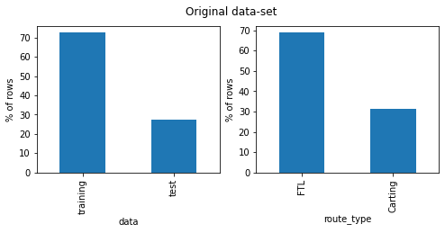

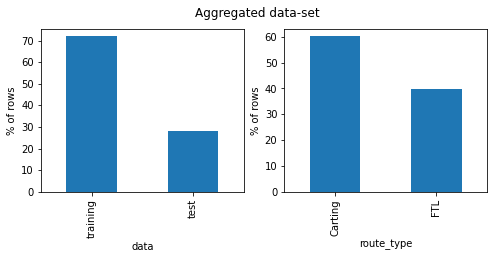

```python
data = df
fig, ax = plt.subplots(1, 2, figsize=(8, 3))
fig.suptitle('Original data-set')
data['data'].value_counts(normalize=True).mul(100).plot(kind='bar', xlabel='data', ylabel='% of rows' ,ax = ax[0])
data['route_type'].value_counts(normalize=True).mul(100).plot(kind='bar', xlabel='route_type', ylabel='% of rows', ax = ax[1])

data = df_aggr2
fig, ax = plt.subplots(1, 2, figsize=(8, 3))
fig.suptitle('Aggregated data-set')
data['data'].value_counts(normalize=True).mul(100).plot(kind='bar', xlabel='data', ylabel='% of rows' ,ax = ax[0])
data['route_type'].value_counts(normalize=True).mul(100).plot(kind='bar', xlabel='route_type', ylabel='% of rows', ax = ax[1])

plt.show()
```

**Observations**

1. The original data-set contains approximately 70% training data and 30% test data. After we aggregate data at trip level, the ratio of training/test data remains identical.
2. The original data-set contains close to 70% rows where route_type is 'FTL' and 30% rows where route_type is 'Carting'. After aggregating the data-set at trip level, the percent of 'Carting' rwos goes up to approximately 60% while that of 'FTL' comes down to around 40%. This implies that there are more trips with 'Carting' route_type than FTL, however, average number of checkpoints in 'FTL' trips are much higher than that in 'Carting' trips.

### Continuous variables

#### Continuous variables in the original data-set

```python
#check statistical parameters for various countnuous variables.
def getnumcols(df):
    return [col for col in df.columns if (df[col].dtype.kind in 'iufc')]
cols_cont = getnumcols(df)

df[cols_cont].describe()
```

|  | start_scan_to_end_scan | actual_distance_to_destination | actual_time | osrm_time | osrm_distance | factor | segment_actual_time | segment_osrm_time | segment_osrm_distance | segment_factor |
| --- | --- | --- | --- | --- | --- | --- | --- | --- | --- | --- |
| count | 144867.000000 | 144867.000000 | 144867.000000 | 144867.000000 | 144867.000000 | 144867.000000 | 144867.000000 | 144867.000000 | 144867.00000 | 144867.000000 |
| mean | 961.262986 | 234.073372 | 416.927527 | 213.868272 | 284.771297 | 2.120107 | 36.196111 | 18.507548 | 22.82902 | 2.218368 |
| std | 1037.012769 | 344.990009 | 598.103621 | 308.011085 | 421.119294 | 1.715421 | 53.571158 | 14.775960 | 17.86066 | 4.847530 |
| min | 20.000000 | 9.000045 | 9.000000 | 6.000000 | 9.008200 | 0.144000 | -244.000000 | 0.000000 | 0.00000 | -23.444444 |
| 25% | 161.000000 | 23.355874 | 51.000000 | 27.000000 | 29.914700 | 1.604264 | 20.000000 | 11.000000 | 12.07010 | 1.347826 |
| 50% | 449.000000 | 66.126571 | 132.000000 | 64.000000 | 78.525800 | 1.857143 | 29.000000 | 17.000000 | 23.51300 | 1.684211 |
| 75% | 1634.000000 | 286.708875 | 513.000000 | 257.000000 | 343.193250 | 2.213483 | 40.000000 | 22.000000 | 27.81325 | 2.250000 |
| max | 7898.000000 | 1927.447705 | 4532.000000 | 1686.000000 | 2326.199100 | 77.387097 | 3051.000000 | 1611.000000 | 2191.40370 | 574.250000 |

We now look at distributions of 'actual_time' (cumulative), 'osrm_time' (cumulative), 'segment_actual_time', 'segment_osrm_time', 'osrm_distance', 'segment_osrm_distance', 'actual_distance_to_destination'

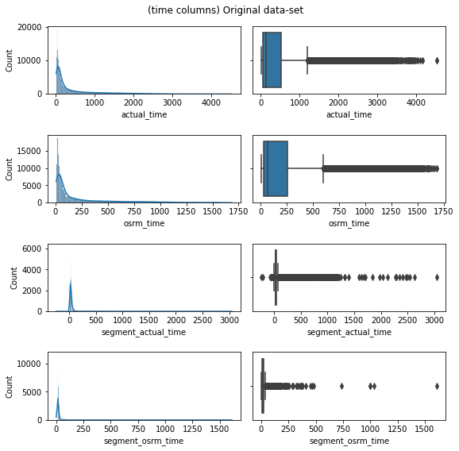

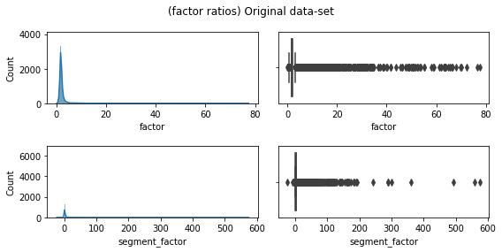

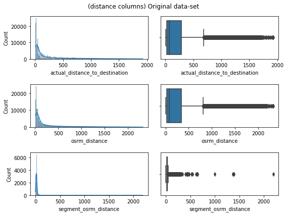

```python
#Analyze indepedent continuous columns
def plotdist(data, cols, title):
    n = len(cols)
    fig, ax = plt.subplots(n, 2, figsize=(8, 2*n))
    fig.suptitle(title)
    for i in range(len(cols)):
        col = cols[i]
        axis = ax[i] if(n > 1) else ax
        sns.histplot(data=data[col], kde=True, ax=axis[0])
        sns.boxplot(x=col, data=data, orient="horizontal", ax=axis[1])
    fig.tight_layout()
    plt.subplots_adjust(hspace=0.6)
    plt.show()

cols = ['actual_time', 'osrm_time', 'segment_actual_time', 'segment_osrm_time']
plotdist(df, cols, '(time columns) Original data-set')

cols = ['factor', 'segment_factor']
plotdist(df, cols, '(factor ratios) Original data-set')

cols = ['actual_distance_to_destination', 'osrm_distance', 'segment_osrm_distance']
plotdist(df, cols, '(distance columns) Original data-set')
```

```python
#check skewness and kurtoises
pd.concat([df[cols_cont].skew(), df[cols_cont].kurt()], axis = 1).rename(columns={0:'skew', 1:'kurtoises'})
```

|  | skew | kurtoises |
| --- | --- | --- |
| start_scan_to_end_scan | 1.110624 | -0.051149 |
| actual_distance_to_destination | 1.991105 | 3.397661 |
| actual_time | 2.068065 | 3.962915 |
| osrm_time | 2.045166 | 3.755795 |
| osrm_distance | 2.048236 | 3.734448 |
| factor | 17.490811 | 491.177641 |
| segment_actual_time | 16.827413 | 494.496398 |
| segment_osrm_time | 19.639634 | 1444.561243 |
| segment_osrm_distance | 26.585363 | 2317.333310 |
| segment_factor | 47.372766 | 4037.388713 |

#### Satistical parameters for continuous variables in the aggregated data-set

```python
#check statistical parameters for various countnuous variables.
cols_cont = [col for col in df_aggr2.columns if (df_aggr2[col].dtype.kind in 'iufc')]
df_aggr2[cols_cont].describe().T
```

|  | count | mean | std | min | 25% | 50% | 75% | max |
| --- | --- | --- | --- | --- | --- | --- | --- | --- |
| actual_time_agg | 14817.0 | 353.003172 | 557.325096 | 9.000000 | 66.00000 | 145.000000 | 367.000000 | 6187.000000 |
| segment_actual_time_agg | 14817.0 | 353.892286 | 556.247965 | 9.000000 | 66.00000 | 147.000000 | 367.000000 | 6230.000000 |
| osrm_time_agg | 14817.0 | 161.138355 | 271.062452 | 6.000000 | 29.00000 | 60.000000 | 168.000000 | 1998.000000 |
| segment_osrm_time_agg | 14817.0 | 180.949787 | 314.542047 | 6.000000 | 31.00000 | 65.000000 | 185.000000 | 2564.000000 |
| actual_distance_to_destination_agg | 14817.0 | 164.682943 | 305.561548 | 9.002461 | 22.86003 | 48.499937 | 164.853324 | 2187.483994 |
| osrm_distance_agg | 14817.0 | 204.249399 | 370.183781 | 9.072900 | 30.84630 | 65.606900 | 207.521100 | 2804.709500 |
| segment_osrm_distance_agg | 14817.0 | 223.201161 | 416.628374 | 9.072900 | 32.65450 | 70.154400 | 218.802400 | 3523.632400 |
| start_scan_to_end_scan | 14817.0 | 546.960991 | 668.656823 | 23.000000 | 151.00000 | 288.000000 | 673.000000 | 7898.000000 |
| factor | 14817.0 | 2.611391 | 2.174422 | 0.270000 | 1.74000 | 2.090000 | 2.720000 | 70.000000 |

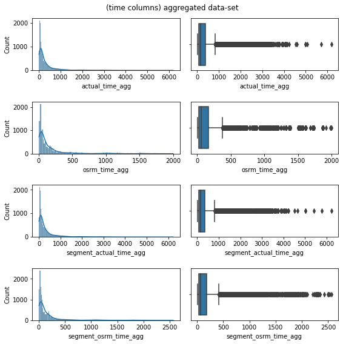

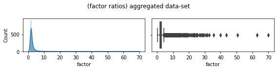

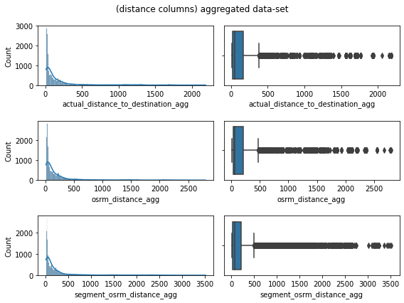

```python
#plot distributions of variables in the aggregated data-set
cols = ['actual_time_agg', 'osrm_time_agg', 'segment_actual_time_agg', 'segment_osrm_time_agg']
plotdist(df_aggr2, cols, '(time columns) aggregated data-set')

cols = ['factor']
plotdist(df_aggr2, cols, '(factor ratios) aggregated data-set')

cols = ['actual_distance_to_destination_agg', 'osrm_distance_agg', 'segment_osrm_distance_agg']
plotdist(df_aggr2, cols, '(distance columns) aggregated data-set')
```

```python
#check skewness and kurtoises
pd.concat([df_aggr2[cols_cont].skew(), df_aggr2[cols_cont].kurt()], axis = 1).rename(columns={0:'skew', 1:'kurtoises'})
```

|  | skew | kurtoises |
| --- | --- | --- |
| actual_time_agg | 3.361614 | 13.617328 |
| segment_actual_time_agg | 3.365921 | 13.798969 |
| osrm_time_agg | 3.448921 | 13.193313 |
| segment_osrm_time_agg | 3.597829 | 14.547415 |
| actual_distance_to_destination_agg | 3.558780 | 13.694012 |
| osrm_distance_agg | 3.550099 | 13.793937 |
| segment_osrm_distance_agg | 3.710119 | 15.357322 |
| start_scan_to_end_scan | 2.768892 | 10.188852 |
| factor | 9.111707 | 165.133653 |

**Observations**

1. In the **original data-set**, we observe that distribution of various time variables (actual, osrm, segment_actual, and segment_osrm), distance variables (osrm_distance, segment_odrm_distance, actual_distance_to_destination), and factor ratios (factor and segment_factor) are all **right skewed with several outliers.**
2. Similarly, in the **aggregated data-set** as well, all aggregated time, distance, and factor ratio columns are right skewed with several outliers.

**Notes:**

1. In the outliers analysis section, we further check the number of outliers and examine ways to treat them.
2. Our data values do not follow normal distribution. In the hypothesis testing section, we check various alternatives to deal with non-normality of the data.

## Bi-variate analysis

We will perform bi-variate analysis only on the aggregated data-set.

### pair plots and correlation (for continuous variables)

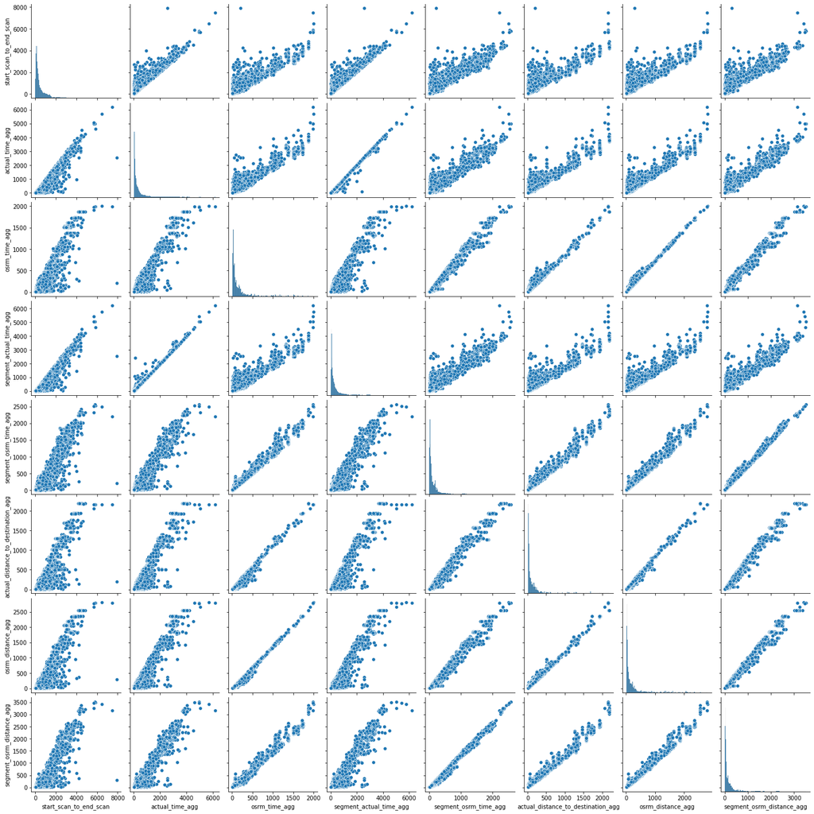

```python
#pair plot to view correlation among various time and distance variables.
df_time_dist_features = df_aggr2[['start_scan_to_end_scan', 'actual_time_agg', 'osrm_time_agg', 'segment_actual_time_agg', 'segment_osrm_time_agg', 'actual_distance_to_destination_agg', 'osrm_distance_agg', 'segment_osrm_distance_agg']]
sns.pairplot(df_time_dist_features)
plt.show()
```

```python
corr_df = df_time_dist_features.corr(method='pearson')
corr_df
```

|  | start_scan_to_end_scan | actual_time_agg | osrm_time_agg | segment_actual_time_agg | segment_osrm_time_agg | actual_distance_to_destination_agg | osrm_distance_agg | segment_osrm_distance_agg |
| --- | --- | --- | --- | --- | --- | --- | --- | --- |
| start_scan_to_end_scan | 1.000000 | 0.950480 | 0.915690 | 0.952656 | 0.907616 | 0.907187 | 0.912889 | 0.907676 |
| actual_time_agg | 0.950480 | 1.000000 | 0.960458 | 0.997866 | 0.955157 | 0.956301 | 0.961056 | 0.958266 |
| osrm_time_agg | 0.915690 | 0.960458 | 1.000000 | 0.957542 | 0.993268 | 0.993813 | 0.997602 | 0.991609 |
| segment_actual_time_agg | 0.952656 | 0.997866 | 0.957542 | 1.000000 | 0.953039 | 0.953141 | 0.958154 | 0.956106 |
| segment_osrm_time_agg | 0.907616 | 0.955157 | 0.993268 | 0.953039 | 1.000000 | 0.987727 | 0.991853 | 0.996092 |
| actual_distance_to_destination_agg | 0.907187 | 0.956301 | 0.993813 | 0.953141 | 0.987727 | 1.000000 | 0.997461 | 0.993257 |
| osrm_distance_agg | 0.912889 | 0.961056 | 0.997602 | 0.958154 | 0.991853 | 0.997461 | 1.000000 | 0.994717 |
| segment_osrm_distance_agg | 0.907676 | 0.958266 | 0.991609 | 0.956106 | 0.996092 | 0.993257 | 0.994717 | 1.000000 |

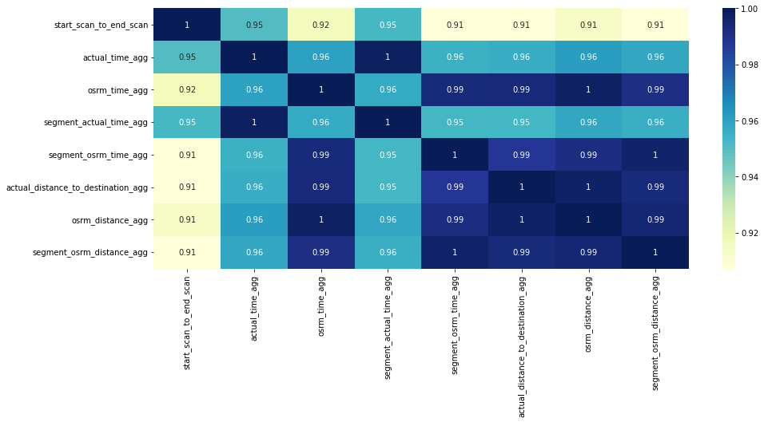

```python
#plot heatmap
plt.figure(figsize=(15,6))
sns.heatmap(corr_df, cmap="YlGnBu", annot=True)
plt.show()
```

**Observations**

1. We see strong correlation (> 0.9) among all time variables (both cumulative and non-cumulative) - start_scan_to_end_scan, actual_time_agg, osrm_time_agg, segment_actual_time_agg, segment_osrm_time_agg.
2. We see very high correlation (> 0.99) among all distance variables (both cumulative and non-cumulative) - actual_distance_to_destination_agg, osrm_distance_agg, segment_osrm_distance_agg.
3. We also see strong correlation between time and distance variables (both cumulative and non-cumulative). In fact, we see all pairs of time and distance variables highly correlated. This confirms our general understanding that in general, longer distance takes longer time and vice-versa. We can visually see the correlation in the pair plot.

### Time variables analysis

#### Distributions of time variables for various categorical variables

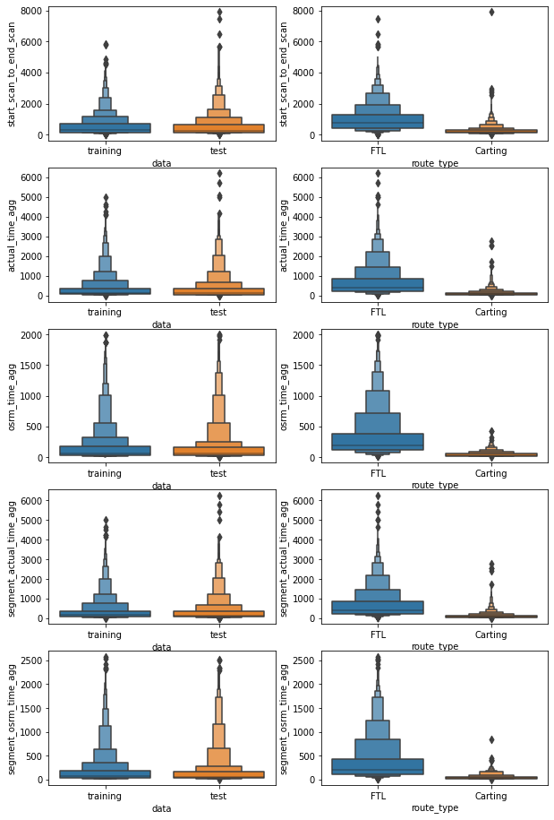

```python
data = df_aggr2

fig, ax = plt.subplots(5, 2, figsize=(10, 16))

sns.boxenplot(x='data', y='start_scan_to_end_scan', data=data, ax=ax[0][0])
sns.boxenplot(x='route_type', y='start_scan_to_end_scan', data=data, ax=ax[0][1])

sns.boxenplot(x='data', y='actual_time_agg', data=data, ax=ax[1][0])
sns.boxenplot(x='route_type', y='actual_time_agg', data=data, ax=ax[1][1])

sns.boxenplot(x='data', y='osrm_time_agg', data=data, ax=ax[2][0])
sns.boxenplot(x='route_type', y='osrm_time_agg', data=data, ax=ax[2][1])

sns.boxenplot(x='data', y='segment_actual_time_agg', data=data, ax=ax[3][0])
sns.boxenplot(x='route_type', y='segment_actual_time_agg', data=data, ax=ax[3][1])

sns.boxenplot(x='data', y='segment_osrm_time_agg', data=data, ax=ax[4][0])
sns.boxenplot(x='route_type', y='segment_osrm_time_agg', data=data, ax=ax[4][1])

plt.show()
```

#### mean value for time variables for each categorical variables

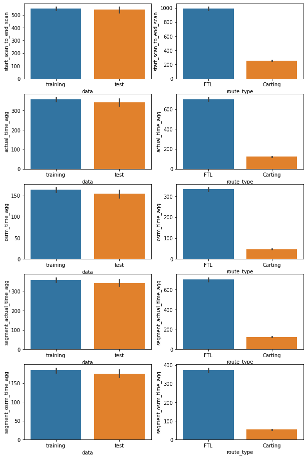

```python
fig, ax = plt.subplots(5, 2, figsize=(10, 16))

sns.barplot(x='data', y='start_scan_to_end_scan',ci=95, data=data, ax=ax[0][0])
sns.barplot(x='route_type', y='start_scan_to_end_scan', ci=95, data=data, ax=ax[0][1])

sns.barplot(x='data', y='actual_time_agg',ci=95, data=data, ax=ax[1][0])
sns.barplot(x='route_type', y='actual_time_agg', ci=95, data=data, ax=ax[1][1])

sns.barplot(x='data', y='osrm_time_agg',ci=95, data=data, ax=ax[2][0])
sns.barplot(x='route_type', y='osrm_time_agg', ci=95, data=data, ax=ax[2][1])

sns.barplot(x='data', y='segment_actual_time_agg',ci=95, data=data, ax=ax[3][0])
sns.barplot(x='route_type', y='segment_actual_time_agg', ci=95, data=data, ax=ax[3][1])

sns.barplot(x='data', y='segment_osrm_time_agg',ci=95, data=data, ax=ax[4][0])
sns.barplot(x='route_type', y='segment_osrm_time_agg', ci=95, data=data, ax=ax[4][1])

plt.show()
```

### Distance variables analysis

#### Distributions of distance variables for various categorical variables

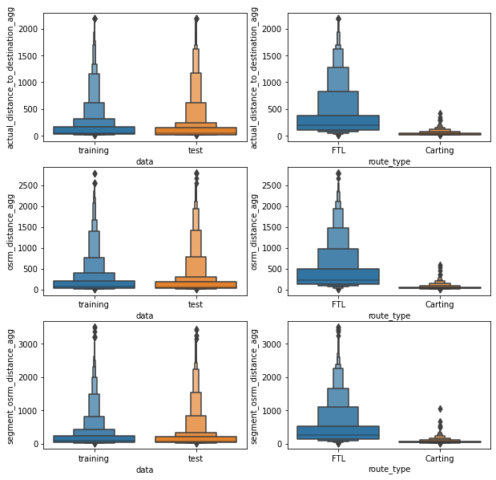

```python
fig, ax = plt.subplots(3, 2, figsize=(10, 10))

sns.boxenplot(x='data', y='actual_distance_to_destination_agg', data=data, ax=ax[0][0])
sns.boxenplot(x='route_type', y='actual_distance_to_destination_agg', data=data, ax=ax[0][1])

sns.boxenplot(x='data', y='osrm_distance_agg', data=data, ax=ax[1][0])
sns.boxenplot(x='route_type', y='osrm_distance_agg', data=data, ax=ax[1][1])

sns.boxenplot(x='data', y='segment_osrm_distance_agg', data=data, ax=ax[2][0])
sns.boxenplot(x='route_type', y='segment_osrm_distance_agg', data=data, ax=ax[2][1])

plt.show()
```

#### mean value of distance variables for various categorical variables

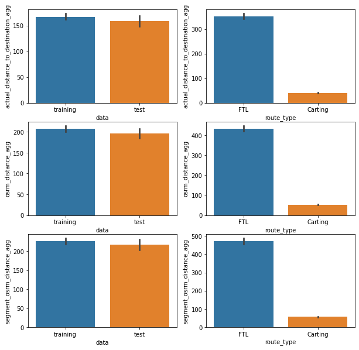

```python
fig, ax = plt.subplots(3, 2, figsize=(10, 10))

sns.barplot(x='data', y='actual_distance_to_destination_agg',ci=95, data=data, ax=ax[0][0])
sns.barplot(x='route_type', y='actual_distance_to_destination_agg', ci=95, data=data, ax=ax[0][1])

sns.barplot(x='data', y='osrm_distance_agg',ci=95, data=data, ax=ax[1][0])
sns.barplot(x='route_type', y='osrm_distance_agg', ci=95, data=data, ax=ax[1][1])

sns.barplot(x='data', y='segment_osrm_distance_agg',ci=95, data=data, ax=ax[2][0])
sns.barplot(x='route_type', y='segment_osrm_distance_agg', ci=95, data=data, ax=ax[2][1])

plt.show()
```

**Observations**

1. Based on distribution plots for both time and distance variables, we observe that *median value* for 'Carting' route_type data is less than that of 'FTL' route_type. Similarly, based on the mean value plot for both time and distance variables, we observe that *mean value* for 'Carting' route_type data is significantly lower than that of 'FTL' route_type. This implies that **trips with route_type 'Carting' are associated with shorter time and distance, whereas, trips with route_type 'FTL' are associated with longer time and distance.**
2. We see that for all time and distance variables, the distributions of training and test data are identical. Similarly, for all variables, mean values are identical between the training and test data. **Thus division of training and test data seem reasonable.**

## Outliers analysis

In this section, we focus only on aggregated data-set. We consider as outliers all the values which fall outside of the interval **[q1 - 1.5 * IQR, q3 + 1.5 * IQR]**, where q1 is 25% percentile value, q3 is 75% percentile value, and IQR is interquartile range which is equal to (q3-q1). We find outliers for the original aggregated data as well as for log-transformed, sqrt-transformed, and cube-root transformed data.

```python
def findoutliers(arr):
    q3 = np.percentile(arr, 75)
    q1 = np.percentile(arr, 25)
    iqr = q3-q1
    ulim = q3 + 1.5*iqr
    llim = q1 - 1.5*iqr
    return pd.Series([True if((ele > ulim) or (ele < llim)) else False for ele in arr])

def makepositive(s, pos_val=0.01):
    return s.transform(lambda val: val if(val > 0) else pos_val)
```

```python
data = df_aggr2
outliers = []
transformations = [
    ('  original', lambda s:s),
    ('sqrt', lambda s: makepositive(s)**(1/2)),
    ('cuberoot', lambda s: makepositive(s)**(1/3)),
    (' log', lambda s: np.log(makepositive(s)))]

total_n = data.shape[0]
for col in getnumcols(data):
    for trans_name, trans_fn in transformations:
        ret = findoutliers(trans_fn(data[col]))
        outliers_n = ret.sum()
        outliers.append([col, trans_name, outliers_n, np.round((outliers_n / total_n) * 100, 2)])

print(f'total number of rows in aggregated dataset: {total_n}')
outliers_df = pd.DataFrame(data=outliers, columns=['column', 'transformation', 'outliers count', 'outliers as % of total rows'])

outliers_df = outliers_df.set_index(keys=['column', 'transformation'])
outliers_df.unstack()
```

```
total number of rows in aggregated dataset: 14817
```

| transformation column | outliers count original | outliers count log | outliers count cuberoot | outliers count sqrt | outliers as % of total rows original | outliers as % of total rows log | outliers as % of total rows cuberoot | outliers as % of total rows sqrt |
| --- | --- | --- | --- | --- | --- | --- | --- | --- |
| actual_distance_to_destination_agg | 1449 | 0 | 702 | 889 | 9.78 | 0.00 | 4.74 | 6.00 |
| actual_time_agg | 1625 | 5 | 660 | 864 | 10.97 | 0.03 | 4.45 | 5.83 |
| factor | 1335 | 819 | 1002 | 1094 | 9.01 | 5.53 | 6.76 | 7.38 |
| osrm_distance_agg | 1527 | 0 | 697 | 924 | 10.31 | 0.00 | 4.70 | 6.24 |
| osrm_time_agg | 1511 | 0 | 696 | 857 | 10.20 | 0.00 | 4.70 | 5.78 |
| segment_actual_time_agg | 1643 | 5 | 659 | 861 | 11.09 | 0.03 | 4.45 | 5.81 |
| segment_osrm_distance_agg | 1548 | 0 | 745 | 934 | 10.45 | 0.00 | 5.03 | 6.30 |
| segment_osrm_time_agg | 1492 | 0 | 721 | 895 | 10.07 | 0.00 | 4.87 | 6.04 |
| start_scan_to_end_scan | 1115 | 3 | 362 | 624 | 7.53 | 0.02 | 2.44 | 4.21 |

**Observations**

1. The table above shows outlier percentage for each column of the original aggregated data-set as well as the log transformed, square-root transformed, and cube root transformed data. We observe that in the original aggregated data-set, the percentage of outliers across various columns ranges from **the highest value of 11.09% (for 'segment_actual_time_agg') to the lowest value of 7.53% (for 'start_scan_to_end_scan'). Thus the overall pecentage of outliers in the overall aggregated data-set is rather high.**
2. We also apply log, sqrt, and cube-root transformations on the aggregated data-set before counting the number of outliers. We observe that **log transformation is very effective here in eliminating or reducing the outliers considerably in all the columns except the 'factor' column.**

## Outliers treatment

There are a few potential options in dealing with outliers data, each having specific pros and cons.

**1. Removing outliers** - If the outliers represent noise/error and form a relatively small portion of the actual data, we can consider removing/trimming them. In the current data-set, however, the percentage of outliers is rather large (ranging from 7.53% to 11.09% across columns and the overall combined percentage could be even higher).

**2. Replacing outliers(Winsorization)** - The other option could be to replace the outliers with the suitable percentile value of the data.

**3. Apply log transformation** - As observed in the previous section, the log transformation seems quite effective in removing/reducing the number of outliers significantly (Except for the factor column). If the further intended statistical analysis can work effectively with log-transformed data, we can consider choosing this option. However, there are certain statistical analysis techniques which may not quite yield the same result on log-transformed data as on the original data. For instance, the t-test on the log-transformed data compares geometric means, not the (usual) arithmetic means.

In this case-study, we will create a copy of the aggregated data-set and replace outliers with appropriate percentile values (option 2). In the code below, we evaluate various percentile values for winsorization and select the lowest value which addresses all the outliers. We will use this modified data-set in the hypothesis test section. However, We will not change the original aggregated data-set.

```python
df_outlier_treated = df_aggr2.copy()

import random
from scipy.stats.mstats import winsorize

winsorizedarr = winsorize(df_outlier_treated['actual_time_agg'],(0.05,0.05))

data = df_outlier_treated
outliers = []
transformations = [
    ('    original', lambda s:s),
    ('   90% winsorize', lambda s:winsorize(s,(0.05, 0.05))),
    ('  80% winsorize', lambda s:winsorize(s,(0.1, 0.1))),
    (' 78% winsorize', lambda s:winsorize(s,(0.11, 0.11))),
    ('75% winsorize', lambda s:winsorize(s,(0.125, 0.125))),
]

total_n = data.shape[0]
for col in getnumcols(data):
    for trans_name, trans_fn in transformations:
        ret = findoutliers(trans_fn(data[col]))
        outliers_n = ret.sum()
        outliers.append([col, trans_name, outliers_n, np.round((outliers_n / total_n) * 100, 2)])

print(f'total number of rows in aggregated dataset: {total_n}')
outliers_df = pd.DataFrame(data=outliers, columns=['column', 'winsorization', 'outliers count', 'outliers as % of total rows'])

outliers_df = outliers_df.set_index(keys=['column', 'winsorization'])
outliers_df.unstack()
```

```
total number of rows in aggregated dataset: 14817
```

| winsorization column | outliers count original | outliers count 90% winsorize | outliers count 80% winsorize | outliers count 78% winsorize | outliers count 75% winsorize | outliers as % of total rows original | outliers as % of total rows 90% winsorize | outliers as % of total rows 80% winsorize | outliers as % of total rows 78% winsorize | outliers as % of total rows 75% winsorize |
| --- | --- | --- | --- | --- | --- | --- | --- | --- | --- | --- |
| actual_distance_to_destination_agg | 1449 | 1449 | 0 | 0 | 0 | 9.78 | 9.78 | 0.00 | 0.00 | 0.0 |
| actual_time_agg | 1625 | 1625 | 1625 | 0 | 0 | 10.97 | 10.97 | 10.97 | 0.00 | 0.0 |
| factor | 1335 | 1335 | 0 | 0 | 0 | 9.01 | 9.01 | 0.00 | 0.00 | 0.0 |
| osrm_distance_agg | 1527 | 1527 | 1527 | 0 | 0 | 10.31 | 10.31 | 10.31 | 0.00 | 0.0 |
| osrm_time_agg | 1511 | 1511 | 1511 | 0 | 0 | 10.20 | 10.20 | 10.20 | 0.00 | 0.0 |
| segment_actual_time_agg | 1643 | 1643 | 1643 | 1643 | 0 | 11.09 | 11.09 | 11.09 | 11.09 | 0.0 |
| segment_osrm_distance_agg | 1548 | 1548 | 1548 | 0 | 0 | 10.45 | 10.45 | 10.45 | 0.00 | 0.0 |
| segment_osrm_time_agg | 1492 | 1492 | 1492 | 0 | 0 | 10.07 | 10.07 | 10.07 | 0.00 | 0.0 |
| start_scan_to_end_scan | 1115 | 1115 | 0 | 0 | 0 | 7.53 | 7.53 | 0.00 | 0.00 | 0.0 |

```python
# At around 75% winsorization, we see zero outliers across all the columns. So we will use this value.
for col in getnumcols(df_outlier_treated):
    df_outlier_treated[col] = winsorize(df_outlier_treated[col],(0.125,0.125))

df_outlier_treated2 = df_aggr2.copy()

ret = [False] * len(df_outlier_treated2)
for col in ['actual_time_agg', 'segment_actual_time_agg', 'osrm_time_agg', 'segment_osrm_time_agg']:
    ret = ret | findoutliers(df_outlier_treated2[col])

df_outlier_treated2 = df_outlier_treated2[~ret]

print(len(df_outlier_treated2)/len(df_aggr2) * 100)
```

```
87.14314638590808
```

## Checking relationship between aggregated fields

In this section, we compare relationships between various related time and distance fields visually(scatter plot) and using hypothesis tests. As seen in the previous sections, the various time and distance variables are right skewed and contain several outliers. Since two-sample paired t-test makes an assumption of normally distributed data, it is not suitable for our data-set. We instead use the following two tests.

1. Hypothesis testing using bootstrap CI - We use bootstrap resampling (With replacement) to generate sampling distribution of mean of the difference and also compute confidence interval for the mean of difference. If that confidence interval does not contain zero value (as the null hypothesis assumes zero difference), we get a statistically significant result and reject the null hypothesis of zero difference.
2. wilcoxon's signed rank test - We use this non-parametric test as it doesn't assume normally distributed data.

**Note:** - We use the aggregated dataset without outliers for the hypothesis test. Also, the data-set given to us contain most of its data from sept-2018. In order to generate more random and independent sample, we take a smaller random sample of 5000 rows and perform our hypothesis tests on it.

### Comparing actual_time aggregated value and OSRM time aggregated value

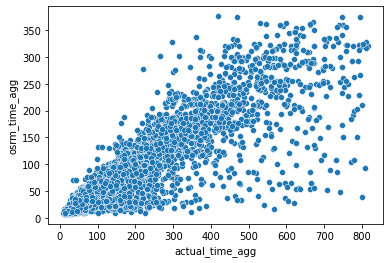

```python
import scipy.stats as stats

#use data without outliers and take a smaller sample
data = df_outlier_treated2.sample(5000)

sns.scatterplot(x='actual_time_agg', y='osrm_time_agg', data=data)
plt.show()
```

**Two-sample paired hypothesis test using bootstrapping CI**

H0: The mean difference between 'actual_time_agg' and 'osrm_time_agg' is zero.

H1: The mean difference is not zero.

```python
#custom bootstrap function
#def bootstrap_mean(data, sample_size=None, n_rep=9999, random_state=None):
#    sample_size = sample_size if (sample_size != None) else len(data)
#    bootstrapped_means = []
#    for rep in range(n_rep):
#        resample = data.sample(n=sample_size, replace=True, random_state = random_state)
#        bootstrapped_means.append(np.mean(resample))
#    conf_interval = np.percentile(bootstrapped_means, [2.5, 97.5])
#    se = np.std(bootstrapped_means)
#    return (conf_interval, se, bootstrapped_means)
```

```
ConfidenceInterval(low=95.86241306408151, high=101.63992246689878)
```

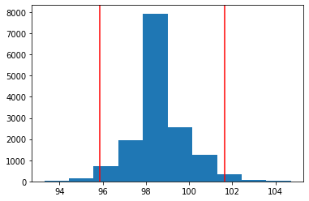

```python
d = (data['actual_time_agg'] - data['osrm_time_agg'])

sample_means = []
def meanfn(sample):
    s_mean = np.mean(sample)
    sample_means.append(s_mean)
    return s_mean

rng = np.random.default_rng(seed=37)
res = stats.bootstrap((d,), meanfn, confidence_level=0.95, vectorized=False,
                random_state=rng, method='BCa')

print(res.confidence_interval)

plt.hist(sample_means)
plt.axvline(x=res.confidence_interval.low, c="r")
plt.axvline(x=res.confidence_interval.high, c="r")
plt.show()
```

**Wilcoxon's signed rank test**

```python
stats.wilcoxon(d)
```

```
WilcoxonResult(statistic=14907.0, pvalue=0.0)
```

**Observations**

1. Hoever, the bootstrap confidence interval for the difference between aggregated actual and osrm time doesn't include the expected null hypothesis difference of zero. Thus we reject the null hypothesis of zero difference.
2. Similarly, the pvalue returned from Wilcoxon's signed rank test is close to zero. Thus we reject the null hypothesis of zero difference.
3. While there indeed is high correlation between aggregated actual and osrm time, we also observe that the *mean of the paired difference is significantly different from zero*(null hypothesis value).
4. Thus we can state at 95% confidence level that there is a significant difference between the aggregated actual time and osrm time. This is also visible in the scatter plot where we see a large deviation away from the diagonal line x=y.

**Recommendation for DS team**

There is an overall significant difference between the actual delivery time versus the predicted delivery time (from OSRM). This presents a potential opportunity for the data science team to adjust osrm prediction with expected delays based on the historical data. At the same time, this is an opportunity for Logistics team to find and eliminate any factors which may be contributing to the overall delay.

### Comparing actual_time aggregated value and segment actual time aggregated value

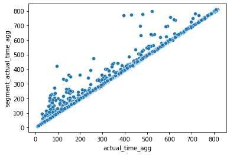

```python
sns.scatterplot(x='actual_time_agg', y='segment_actual_time_agg', data=data)
```

**Two-sample paired hypothesis test using bootstrapping CI**

H0: The mean difference between 'actual_time_agg' and 'segment_actual_time_agg' is zero.

H1: The mean difference is not zero.

```
ConfidenceInterval(low=-1.5475363959194206, high=-0.5629428013248543)
```

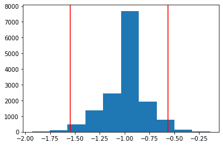

```python
d = (data['actual_time_agg'] - data['segment_actual_time_agg'])

sample_means = []

rng = np.random.default_rng(seed=37)
res = stats.bootstrap((d,), meanfn, confidence_level=0.95, vectorized=False,
                random_state=rng, method='BCa')

print(res.confidence_interval)

plt.hist(sample_means)
plt.axvline(x=res.confidence_interval.low, c="r")
plt.axvline(x=res.confidence_interval.high, c="r")
plt.show()
```

**Wilcoxon's signed rank test**

```python
stats.wilcoxon(d)
```

```
WilcoxonResult(statistic=902412.0, pvalue=0.0)
```

**Observations**

1. The bootstrap confidence interval for the difference between aggregated actual and aggregated segment actual time doesn't include the expected null hypothesis difference of zero. Thus we reject the null hypothesis of zero difference.
2. Similarly, the pvalue returned from Wilcoxon's signed rank test is close to zero. Thus we reject the null hypothesis of zero difference.
3. While there indeed is high correlation between aggregated actual and aggregated segment actual time, we also observe that the *mean of the paired difference is significantly different from zero*(null hypothesis value).
4. Thus we can state at 95% confidence level that there is a significant difference between the aggregated actual time and aggregated segment actual time. We can also verify this visually. In the scatterplot between the two variables, while there are many observations which fall near the diagonal line x=y, there are also high number of deviations away from the diagonal line.

**Recommendation for DS team**

There is an overall significant difference between the aggregated actual delivery time versus the aggregated segment actual delivery time (from OSRM). This is an unexpected finding. This presents a potential opportunity for the data science team to investigate why the sum of segmented time is different from the cumulative actual time.

### Comparing osrm time aggregated value and segment osrm time aggregated value

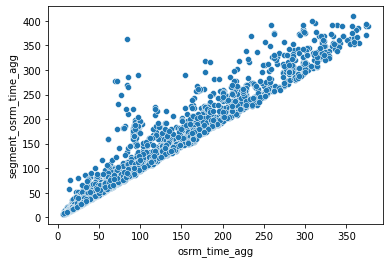

```python
sns.scatterplot(x='osrm_time_agg', y='segment_osrm_time_agg', data=data)
```

**Two-sample paired hypothesis test using bootstrapping CI**

H0: The mean difference between 'osrm_time_agg' and 'segment_osrm_time_agg' is zero.

H1: The mean difference is not zero.

```
ConfidenceInterval(low=-8.257253212059139, high=-7.185702402042958)
```

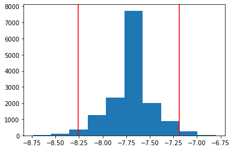

```python
d = (data['osrm_time_agg'] - data['segment_osrm_time_agg'])

sample_means = []

rng = np.random.default_rng(seed=37)
res = stats.bootstrap((d,), meanfn, confidence_level=0.95, vectorized=False,
                random_state=rng, method='BCa')

print(res.confidence_interval)

plt.hist(sample_means)
plt.axvline(x=res.confidence_interval.low, c="r")
plt.axvline(x=res.confidence_interval.high, c="r")
plt.show()
```

**Wilcoxon's signed rank test**

```python
stats.wilcoxon(d)
```

```
WilcoxonResult(statistic=1836839.5, pvalue=4.4693343307340444e-206)
```

**Observations**

1. The bootstrap confidence interval for the difference between aggregated osrm and aggregated segment osrm time doesn't include the expected null hypothesis difference of zero. Thus we reject the null hypothesis of zero difference.
2. Similarly, the pvalue returned from Wilcoxon's signed rank test is close to zero. Thus we reject the null hypothesis of zero difference.
3. While there indeed is high correlation between aggregated osrm and aggregated segment osrm time, we also observe that the *mean of the paired difference is significantly different from zero*(null hypothesis value).
4. Thus we can state at 95% confidence level that there is a significant difference between the aggregated osrm time and aggregated segment osrm time. We can also verify this visually. In the scatterplot between the two variables, while there are many observations which fall near the diagonal line x=y, there are also high number of deviations away from the diagonal line.

**Recommendation for DS team**

There is an overall significant difference between the aggregated osrm delivery time versus the aggregated segment osrm delivery time (from OSRM). Since OSRM is dynamic in nature, this may or may not be unexpected depending on how the cumulative osrm values are computed. This presents a potential opportunity for the data science team to investigate further.

### Comparing osrm distance aggregated value and segment osrm distance aggregated value

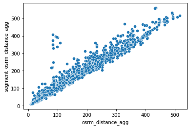

```python
sns.scatterplot(x='osrm_distance_agg', y='segment_osrm_distance_agg', data=data)
```

**Two-sample paired hypothesis test using bootstrapping CI**

H0: The mean difference between 'osrm_ditance_agg' and 'segment_osrm_distance_agg' is zero.

H1: The mean difference is not zero.

```
ConfidenceInterval(low=-7.035239380201518, high=-5.943864044429519)
```

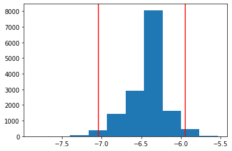

```python
d = (data['osrm_distance_agg'] - data['segment_osrm_distance_agg'])

sample_means = []

rng = np.random.default_rng(seed=37)
res = stats.bootstrap((d,), meanfn, confidence_level=0.95, vectorized=False,
                random_state=rng, method='BCa')

print(res.confidence_interval)

plt.hist(sample_means)
plt.axvline(x=res.confidence_interval.low, c="r")
plt.axvline(x=res.confidence_interval.high, c="r")
plt.show()
```

**Wilcoxon's signed rank test**

```python
stats.wilcoxon(d)
```

```
WilcoxonResult(statistic=1482896.5, pvalue=6.028593832429975e-267)
```

**Observations**

1. The bootstrap confidence interval for the difference between aggregated osrm and aggregated segment osrm distance doesn't include the expected null hypothesis difference of zero. Thus we reject the null hypothesis of zero difference.
2. Similarly, the pvalue returned from Wilcoxon's signed rank test is close to zero. Thus we reject the null hypothesis of zero difference.
3. While there indeed is high correlation between aggregated osrm and aggregated segment osrm distance, we also observe that the *mean of the paired difference is significantly different from zero*(null hypothesis value).
4. Thus we can state at 95% confidence level that there is a significant difference between the aggregated osrm distance and aggregated segment osrm distance. We can also verify this visually. In the scatterplot between the two variables, while there are many observations which fall near the diagonal line x=y, there are also high number of deviations away from the diagonal line.

## Feature creation

1. Destination Name: Split and extract features out of destination. City-place-code (State)
2. Source Name: Split and extract features out of destination. City-place-code (State)
3. Trip_creation_time: Extract features like month, year and day etc

### Create features from source name and destination name

The usual format of source_name and destination*name values is **\<city>*\<place>_\<code>(state)**. We use regular expressions to extract individual components and create 8 new features; city, place, code, and state for both source and destination.

**Note:** There are some values where character '_' comes in the actual name. For instance 'Surat_Central_I_4 (Gujarat)' and 'GZB_Mohan_Nagar_DPC (Uttar Pradesh)'. Since there's is no clearly defined rule to correctly identify each components in the presence of additional underscores in the data, we follow the rule stated below.

All the characters preceding the first underscore represent 'city' value. Similarly, all the characters between the first and second underscores represent 'place' component. All the character between the second underscore and the left parenthesis (including any additional underscores) are considered 'code' components. Finally, the value inside the round parenthesis is considered state component.

```python
#Destination Name: Split and extract features out of destination. City_place_code(State)

data = df_aggr2

import re
regx = re.compile(r'^([^_]*)(?:_([^_]*))?(?:_(.*))?\((.*)\)$')

def getmatchcomp(str, grpno):
    m = regx.match(str)
    if(m != None and m.groups != None):
        grps = m.groups()
        if(grps != None and grpno < len(grps) and grps[grpno] != None):
            return grps[grpno]
    return 'NA'

def process_name(val):
    if(val != None):
        #convert to lower
        val = val.lower()
        #remove spaces
        val = val.replace(' ', '')
    return val

def correct_city(city):
    city = process_name(city)

    city_map = {
        'bengaluru': 'bengaluru',
        'bangalore': 'bengaluru',
        'nowda': 'noida'
    }
    #TODO: add more corrections in map above
    if(city in city_map.keys()):
        city=city_map[city]

    return city

for data in [df, df_agg_first_level, df_aggr2]:
    data['s_city'] = data['source_name'].apply(lambda x: correct_city(getmatchcomp(x, 0)))
    data['s_place'] = data['source_name'].apply(lambda x: process_name(getmatchcomp(x, 1)))
    data['s_code'] = data['source_name'].apply(lambda x: process_name(getmatchcomp(x, 2)))
    data['s_state'] = data['source_name'].apply(lambda x: process_name(getmatchcomp(x, 3)))

    data['d_city'] = data['destination_name'].apply(lambda x: correct_city(getmatchcomp(x, 0)))
    data['d_place'] = data['destination_name'].apply(lambda x: process_name(getmatchcomp(x, 1)))
    data['d_code'] = data['destination_name'].apply(lambda x: process_name(getmatchcomp(x, 2)))
    data['d_state'] = data['destination_name'].apply(lambda x: process_name(getmatchcomp(x, 3)))

data[['source_name', 's_city', 's_place', 's_code', 's_state', 'destination_name', 'd_city', 'd_place', 'd_code', 'd_state']].head(5)
```

|  | source_name | s_city | s_place | s_code | s_state | destination_name | d_city | d_place | d_code | d_state |
| --- | --- | --- | --- | --- | --- | --- | --- | --- | --- | --- |
| 0 | Bhopal_Trnsport_H (Madhya Pradesh) | bhopal | trnsport | h | madhyapradesh | Gurgaon_Bilaspur_HB (Haryana) | gurgaon | bilaspur | hb | haryana |
| 1 | Tumkur_Veersagr_I (Karnataka) | tumkur | veersagr | i | karnataka | Chikblapur_ShntiSgr_D (Karnataka) | chikblapur | shntisgr | d | karnataka |
| 2 | Bangalore_Nelmngla_H (Karnataka) | bengaluru | nelmngla | h | karnataka | Chandigarh_Mehmdpur_H (Punjab) | chandigarh | mehmdpur | h | punjab |
| 3 | Mumbai Hub (Maharashtra) | mumbaihub | na | na | maharashtra | Mumbai_MiraRd_IP (Maharashtra) | mumbai | mirard | ip | maharashtra |
| 4 | Bellary_Dc (Karnataka) | bellary | dc | na | karnataka | Bellary_Dc (Karnataka) | bellary | dc | na | karnataka |

### Create features from Trip_creation_time

```python
#create year, month,and day features from trip_creation_time
data['ct_year'] = data['trip_creation_time'].dt.year
data['ct_month'] = data['trip_creation_time'].dt.month
data['ct_day'] = data['trip_creation_time'].dt.day

print(data['ct_year'].value_counts())
print('\n')
print(data['ct_month'].value_counts())
print('\n')
print(data['ct_day'].value_counts())

data[['trip_creation_time', 'ct_year', 'ct_month', 'ct_day']].sample(5)
```

```
2018    14817
Name: ct_year, dtype: int64


9     13029
10     1788
Name: ct_month, dtype: int64


18    791
15    783
13    750
12    747
21    740
22    740
```

[output cut: 17 more lines]

|  | trip_creation_time | ct_year | ct_month | ct_day |
| --- | --- | --- | --- | --- |
| 11987 | 2018-09-29 01:30:51.318072 | 2018 | 9 | 29 |
| 2460 | 2018-09-15 06:05:41.613364 | 2018 | 9 | 15 |
| 466 | 2018-09-12 17:33:39.498320 | 2018 | 9 | 12 |
| 11978 | 2018-09-29 01:15:44.703806 | 2018 | 9 | 29 |
| 4045 | 2018-09-17 18:20:42.819693 | 2018 | 9 | 17 |

### One-hot encoding of categorical variables

We one-hot encode route_type and data variables.

```python
df_aggr2 = pd.get_dummies(df_aggr2, columns = ['route_type', 'data'])
```

### Standardization/Normalization

As seen in the previous sections, our data contains a lot of outiers. Standardization usually is more robust against outliers compared to min-max normalization. We will standardize all distance and time columns in the aggregated data set.

```python
data = df_aggr2

# standardization
from sklearn.preprocessing import StandardScaler
zscaler = StandardScaler()

for col in ['actual_time_agg', 'osrm_time_agg', 'segment_actual_time_agg', 'segment_osrm_time_agg', 'osrm_distance_agg', 'segment_osrm_distance_agg', 'actual_distance_to_destination_agg', 'start_scan_to_end_scan']:
    colname = col + '_z'
    arr = data[col].to_numpy().reshape(-1,1)
    data[colname] = zscaler.fit_transform(arr)
```

### Drop unnecessary columns

```python
df_aggr2.drop(labels=['trip_uuid','route_schedule_uuid','source_name','destination_name'], axis=1, inplace=True)
```

```python
### Save final aggregated data-set
df_aggr2.to_csv('delhivery_aggregated_data.csv', index=False)

df_aggr2.head(5).T
```

|  | 0 | 1 | 2 | 3 | 4 |
| --- | --- | --- | --- | --- | --- |
| trip_creation_time | 2018-09-12 00:00:16.535741 | 2018-09-12 00:00:22.886430 | 2018-09-12 00:00:33.691250 | 2018-09-12 00:01:00.113710 | 2018-09-12 00:02:09.740725 |
| source_center | IND462022AAA | IND572101AAA | IND562132AAA | IND400072AAB | IND583101AAA |
| destination_center | IND000000ACB | IND562101AAA | IND160002AAC | IND401104AAA | IND583101AAA |
| od_start_time | 2018-09-12 00:00:16.535741 | 2018-09-12 00:00:22.886430 | 2018-09-12 00:00:33.691250 | 2018-09-12 00:01:00.113710 | 2018-09-12 00:02:09.740725 |
| od_end_time | 2018-09-13 13:40:23.123744 | 2018-09-12 03:01:59.598855 | 2018-09-14 17:34:55.442454 | 2018-09-12 01:41:29.809822 | 2018-09-12 12:00:30.683231 |
| actual_time_agg | 1562.0 | 143.0 | 3072.0 | 59.0 | 341.0 |
| segment_actual_time_agg | 1548.0 | 141.0 | 3308.0 | 59.0 | 340.0 |
| osrm_time_agg | 717.0 | 68.0 | 1726.0 | 15.0 | 117.0 |
| segment_osrm_time_agg | 1008.0 | 65.0 | 1941.0 | 16.0 | 115.0 |
| actual_distance_to_destination_agg | 824.732854 | 73.186911 | 1932.273969 | 17.175274 | 127.4485 |
| osrm_distance_agg | 991.3523 | 85.111 | 2348.3098 | 19.68 | 146.7918 |
| segment_osrm_distance_agg | 1320.4733 | 84.1894 | 2545.2678 | 19.8766 | 146.7919 |
| start_scan_to_end_scan | 2260.0 | 181.0 | 3934.0 | 100.0 | 718.0 |
| factor | 2.18 | 2.1 | 1.78 | 3.93 | 2.91 |
| s_city | bhopal | tumkur | bengaluru | mumbaihub | bellary |
| s_place | trnsport | veersagr | nelmngla | na | dc |
| s_code | h | i | h | na | na |
| s_state | madhyapradesh | karnataka | karnataka | maharashtra | karnataka |
| d_city | gurgaon | chikblapur | chandigarh | mumbai | bellary |
| d_place | bilaspur | shntisgr | mehmdpur | mirard | dc |
| d_code | hb | d | h | ip | na |
| d_state | haryana | karnataka | punjab | maharashtra | karnataka |
| ct_year | 2018 | 2018 | 2018 | 2018 | 2018 |
| ct_month | 9 | 9 | 9 | 9 | 9 |
| ct_day | 12 | 12 | 12 | 12 | 12 |
| route_type_Carting | 0 | 1 | 0 | 1 | 0 |
| route_type_FTL | 1 | 0 | 1 | 0 | 1 |
| data_test | 0 | 0 | 0 | 0 | 0 |
| data_training | 1 | 1 | 1 | 1 | 1 |
| actual_time_agg_z | 2.169358 | -0.376818 | 4.87882 | -0.527543 | -0.021538 |
| osrm_time_agg_z | 2.050747 | -0.343616 | 5.773262 | -0.53915 | -0.16284 |
| segment_actual_time_agg_z | 2.146791 | -0.382742 | 5.310954 | -0.530163 | -0.024976 |
| segment_osrm_time_agg_z | 2.629468 | -0.368643 | 5.595785 | -0.52443 | -0.209676 |
| osrm_distance_agg_z | 2.126321 | -0.321847 | 5.792076 | -0.498605 | -0.155219 |
| segment_osrm_distance_agg_z | 2.633784 | -0.33367 | 5.57366 | -0.48804 | -0.183405 |
| actual_distance_to_destination_agg_z | 2.160194 | -0.299446 | 5.784925 | -0.482759 | -0.12186 |
| start_scan_to_end_scan_z | 2.561997 | -0.547326 | 5.065608 | -0.668469 | 0.255804 |

## Additional Business Insights

In this section, we use the features created in the previous sections to analyze data, answer speific questions, and draw potentially useful insights/recommendations.

### Check from where most orders originate (State, city etc)

```python
total_rows = len(df)
total_trips = len(df_aggr2)

for col in ['s_state', 's_city']:
    print('\n' + str(df_aggr2.groupby(col)[col].agg(lambda x: np.round((len(x) * 100 / total_trips),2)).sort_values(ascending=False).head(5)))
```

```
s_state
maharashtra    18.10
karnataka      15.04
haryana        11.37
tamilnadu       7.32
delhi           5.35
Name: s_state, dtype: float64

s_city
bengaluru    11.95
gurgaon       6.91
bhiwandi      5.47
delhi         4.18
mumbai        3.91
Name: s_city, dtype: float64
```

**Observations**

1. Top 3 states where the most number of orders originate are Maharashtra(18%), Karnataka(15%), and Haryana(11.37%).
2. Top 3 cities where the most number of orders originate are Benguluru(11.95%), Gurgaon(6.91%), and Bhiwandi(5.47%).

### Check where the most orders are delivered (State, city etc)

```python
for col in ['d_state', 'd_city']:
    print(f'\n {df_aggr2.groupby(col)[col].agg(lambda x: np.round((len(x) * 100 / total_trips),2)).sort_values(ascending=False).head(3)}')
```

```
 d_state
maharashtra    17.49
karnataka      15.35
haryana        11.25
Name: d_state, dtype: float64

 d_city
bengaluru    11.49
mumbai        6.01
gurgaon       5.86
Name: d_city, dtype: float64
```

**Observations**

1. Top 3 states where the most number of orders are delivered are Maharashtra(17.49%), Karnataka(15.35%), and Haryana(11.25%).
2. Top 3 cities where the most number of orders are delivered are Bengaluru(11.49%), Mumbai(6%), and Gurgaon(5.86%)

### Busiest, longest, and slowest inter-state corridors

Note: We define an inter-state corridor as a combination of a source state and a destination state such that both of them are different. They represent one-way corridor. This means that (Maharashtra to Gujarat) is different from (Gujarat to Maharashtra).

```python
#we use segment osrm times and distances while aggregating at inter-state level.
#inter-state
filter = (df['s_state'] != df['d_state']) & (df['s_state'] != 'na') & (df['d_state'] != 'na')
df_interstate = df[filter].groupby(['s_state', 'd_state']).agg(count=('d_state', 'count'), avg_distance_osrm=('segment_osrm_distance', np.mean), avg_time_osrm=('segment_osrm_time', np.mean)).reset_index()

res = df_interstate.sort_values(by=['count'])[['s_state', 'd_state', 'count', 'avg_distance_osrm', 'avg_time_osrm']]
print('\nBusiest inter-state corridors')
print(res.tail(3).sort_values(by='count', ascending=False))

res = df_interstate.sort_values(by=['avg_distance_osrm'])[['s_state', 'd_state', 'count', 'avg_distance_osrm', 'avg_time_osrm']]
print('\ninter-state corridors with longest average distance')
print(res.tail(3).sort_values(by='avg_distance_osrm', ascending=False))

res = df_interstate.sort_values(by=['avg_time_osrm'])[['s_state', 'd_state', 'count', 'avg_distance_osrm', 'avg_time_osrm']]
print('\ninter-state corridors with longest average time')
print(res.tail(3).sort_values(by='avg_time_osrm', ascending=False))
```

```
Busiest inter-state corridors
        s_state    d_state  count  avg_distance_osrm  avg_time_osrm
37      haryana  karnataka   4976          30.352581      23.066519
58    karnataka    haryana   3394          30.660306      23.691514
78  maharashtra    haryana   2934          28.669487      21.880709

inter-state corridors with longest average distance
        s_state     d_state  count  avg_distance_osrm  avg_time_osrm
121  westbengal       assam    203          44.466977      31.674877
7         assam   meghalaya     33          42.667479      33.151515
11        assam  westbengal    149          41.793932      29.577181

inter-state corridors with longest average time
       s_state    d_state  count  avg_distance_osrm  avg_time_osrm
105  tamilnadu     kerala     16          30.478794      39.062500
68      kerala  tamilnadu     45          28.830993      33.666667
7        assam  meghalaya     33          42.667479      33.151515
```

### Busiest, longest, and slowest inter-city corridors

Note: We define an inter-city corridor as a combination of a source city and a destination city such that both of them are different. They represent one-way corridor. This means that (Mumbai to Pune) is different from (Pune to Mumbai).

```python
filter = (df['s_city'] != df['d_city']) & (df['s_city'] != 'na') & (df['d_city'] != 'na')
df_intercity = df[filter].groupby(['s_city', 'd_city']).agg(count=('d_city', 'count'), avg_distance_osrm=('segment_osrm_distance', np.mean), avg_time_osrm=('segment_osrm_time', np.mean)).reset_index()

res = df_intercity.sort_values(by=['count'])[['s_city', 'd_city', 'count', 'avg_distance_osrm', 'avg_time_osrm']]
print('\nBusiest inter-city corridors')
print(res.tail(3).sort_values(by='count', ascending=False))

res = df_intercity.sort_values(by=['avg_distance_osrm'])[['s_city', 'd_city', 'count', 'avg_distance_osrm', 'avg_time_osrm']]
print('\ninter-city corridors with longest average distance')
print(res.tail(3).sort_values(by='avg_distance_osrm', ascending=False))

res = df_intercity.sort_values(by=['avg_time_osrm'])[['s_city', 'd_city', 'count', 'avg_distance_osrm', 'avg_time_osrm']]
print('\ninter-city corridors with longest average time')
print(res.tail(3).sort_values(by='avg_time_osrm', ascending=False))
```

```
Busiest inter-city corridors
        s_city     d_city  count  avg_distance_osrm  avg_time_osrm
761    gurgaon  bengaluru   4976          30.352581      23.066519
235  bengaluru    gurgaon   3394          30.660306      23.691514
783    gurgaon    kolkata   2862          26.755446      18.998602

inter-city corridors with longest average distance
         s_city      d_city  count  avg_distance_osrm  avg_time_osrm
1278   lalitpur     gwalior      1           223.2655          208.0
1531  nandurbar       dhule      1           109.1615           79.0
2014      solan  chandigarh      1           101.7296           95.0

inter-city corridors with longest average time
         s_city      d_city  count  avg_distance_osrm  avg_time_osrm
1278   lalitpur     gwalior      1           223.2655          208.0
2014      solan  chandigarh      1           101.7296           95.0
1531  nandurbar       dhule      1           109.1615           79.0
```

**Recommendations**

### Inter-city corridors experiencing maxium average delay

we consider the difference between the segment_actual_time and segment_osrm_time as the delay.

```python
df_temp = df.copy()
filter = (df_temp['s_city'] != df_temp['d_city']) & (df_temp['s_city'] != 'na') & (df_temp['d_city'] != 'na')
df_temp['delay_time'] = df_temp['segment_actual_time'] - df_temp['segment_osrm_time']
df_intercity = df_temp[filter].groupby(['s_city', 'd_city']).agg(avg_delay=('delay_time', np.mean)).reset_index()
df_intercity.sort_values(by='avg_delay', ascending=False).head()
```

|  | s_city | d_city | avg_delay |
| --- | --- | --- | --- |
| 1164 | khatra | hura | 1251.0 |
| 855 | helencha | kolkata | 1059.8 |
| 1531 | nandurbar | dhule | 1014.0 |
| 1875 | sakri | dhule | 884.5 |
| 1932 | shahada | dhule | 820.0 |

**Recommendation**

(Khatra to hura), (helencha to kolkata), and (nadurbar to dhule) are top three inter-city corridors with maxium delays. If these corridors have potential to generate more demands, the business should consider investing more resources to improve delivery time.